# Donar format a text amb Markdown

## Resum de les regles bàsiques:

El format es defineix amb etiquetes específiques per a cada cas:

- El parragraf es forma amb dos return.
- El salt de línia amb dos espais seguits.
- Les cites amb > al principi del text
- Text en itàlica : *...* o _..._
- Text en negreta : **...** o __...__
- Títols : #
- Llistes desordenades : * + espai o _ + espai o + + espai. Per als subnivells es pot precedir d'un espai o el tabulador.
- Llistes ordenades : 1., 2., etc.
- Codi, forma 1 : entre dos `` (``codi``). Equival al \<code> de l'html.
- Codi, forma 2 : precedit de quatre espais en cada línia. Equival al \<pre> de l'html.
- Blocs de codi : entre dues línies formades per tres ~ (~~~)
- Enllaços ocultant l'adreça : el nom entre [] i l'adreça de l'enllaç entre ()
- Enllaços mostrant l'adreça : adreça continguda entre \< i >
- Imatges : !text alternatiu
- *** sense text : Dibuixa una línia horitzontal

## Donar estil al text

- Itàlica : contingut entre asteriscs o subguions : *text* o _text_
  - *Estic entre subguions*. Altre exemple: sóc un text normal *i jo en itàlica*.
- Negreta : contingut entre dobles asteriscs o subguions: **text** o __text__
  - **Estic entre dobles subguions**. Jo sóc un text normal **i jo estic entre dobles asteriscs**.

## Títols

- Els títols van precedits del símbol #.
- N'hi ha fins a sis nivells, en progressió descendent (equivalents a l'etiqueta h1, h2, etc., de l'html).
  - Exemple: # Això serà un títol de nivell 1
- Es poden 'escapar' amb la contrabarra \ :

Mostres:

# Títol nivell 1

## Títol nivell 2

### Títol nivell 3

#### Títol nivell 4

##### Títol nivell 5

###### Títol nivell 6

## Llistes desordenades

* + espai + text

- Nivell 1 de la llista
  - Nivell 2 de la llista

## Llistes ordenades

1. Nivell 1
2. Nivell 1

   2.1. Nivell 2

   2.2. Nivell 2

## Cites

> Sóc una cita.

> Jo també sóc una cita

## Blocs de codi

```
print("Sóc un bloc de codi.")
```

## Enllaços

Ocultant l'adreça : [El meu github](https://github.com/ferran-parellada)

Mostrant l'adreça : https://github.com/ferran-parellada

## Codi amb ``codi``

`Això és una línia de codi`

```
x = "Hola
print(x)
```

## Codi amb quatre espais espais en blanc al principi

```
x = "Hola"
print(x)
```

## Insertar una imatge

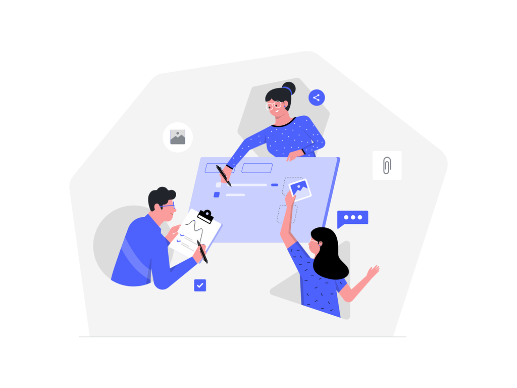

## Exemple fòrmula complexe

Han d'anar contingudes entre $$. La potència s'indica amb ^.

$$e = m * c ^2$$

## Informació sobre Markdown

Una bona referència: [Sintaxis Markdown](https://markdown.es/sintaxis-markdown/#listas)